# PEC1 - Informe (Análisis de datos ómicos)

Irene Martínez Serrano

1/11/2024

# *Abstract*

En esta primera entrega (PEC1), se realizará una aproximación inicial a la exploración de datos ómicos mediante el aprendizaje de herramientas fundamentales en bioinformática. El objetivo es llevar a cabo un análisis completo que incluya la selección de datos de un repositorio metabolómico y la exploración del conjunto de datos mediante análisis univariante y multivariante.

Las herramientas que utilizaremos en este proceso son: **GitHub** como repositorio, **Bioconductor** para la descarga de paquetes (por ejemplo, *SummarizedExperiment*, que servirá como contenedor de nuestros datos) y **R Studio** como software estadístico. El conjunto de datos seleccionado es el *ST000291* de *Metabolomics Workbench*, correspondiente a un estudio que investigó los cambios metabólicos generales causados por el consumo de jugo de arándano o jugo de manzana utilizando un enfoque de metabolómica global.

Una vez descargados los datos y almacenados en el contenedor SummarizedExperiment, fue necesario procesarlos para poder realizar un análisis adecuado.En primer lugar se realizó un análisis univariante descriptivo de los datos, y a continuación se llevó a cabo un análisis multivariante que incluyó el análisis de componentes principales (PCA y técnicas de clustering). Ambos análisis aportaron información similar, puesto que se evidenció que los tratamientos bajo los que se recogieron los datos no distinguen la agrupación de metabolitos recogidos, sinó que existe otro factor (a priori desconocido) que podría caracterizar de forma más certera 2 grupos concretos entre la totalidad de los datos recogidos.

Para más información, este informe, junto con el código y los datos empleados, será subido a un [repositorio de **GitHub**](https://github.com/imartinezserr/Martinez-Serrano-Irene-PEC1) para su revisión y referencia.

# *Objetivos del estudio*

El objetivo principal de esta entrega es aprender a explorar datos ómicos mediante el uso de diversas herramientas clave en bioinformática. Como objetivos secundarios se plantean los siguientes puntos:

- Buscar y seleccionar una base de datos adecuada.
- Procesar los datos y organizar el análisis a seguir.
- Comprender y representar adecuadamente los análisis univariante y multivariante.
- Discutir los resultados obtenidos y las posibles limitaciones del trabajo.
- Garantizar un código reproducible.
- Presentar un informe legible y bien organizado

# *Materiales y Métodos*

A continuación se muestra un esquema del procedimiento a seguir durante esta PEC1 (*Figura 1*).

[figure not shown]

*Figura 1*. Visión general del proceso de exploración de la PEC1.

Brevemente, en el [repositorio metaboData de Github](https://github.com/nutrimetabolomics/metaboData/) hemos seleccionado específicamente el conjunto de datos 2024-fobitools-UseCase_1. Se trata de un estudio de metabolómica global que contiene tres archivos separados:

- **Datos** -> 1541 variables, 45 muestras
- **Metadata** -> 45 filas, dos columnas (nombre de la muestra, nombre del grupo)
- Adicional: **Nombre de metabolitos** -> 1541 filas, 3 columnas (nombre original, ID de PubChem y ID de KEGG)

Aunque estos datos también se encuentran en la interfaz de [*MetabolomicsWorkbench*](https://www.metabolomicsworkbench.org/databases/index.php), decidimos continuar con los datos desCargados desde **Github** puesto que estos ya estan pre-procesados. Tal y como se explica en la descripción del estudio, la parte analítica del estudio consiste en dos métodos diferentes que luego se recogen en un solo dataset puesto que son complementarios.

Como se refleja en la *Figura 1*, las herramientas informáticas y bioinformáticas utilizadas son:

- *Github*
- *Bioconductor*
- *R studio*

Específicamente, de las dos últimas destacamos los paquetes de *SummarizedExperiment* (contendor de datos metabolómicos) y *POMA*, entre otros.

El procedimiento general de análisis consta de diferentes pasos:

1. Selección del dataset (**Github**)
2. Contención del conjunto de datos (*SummarizedExperiment*, **Bioconductor**)
3. Procesado del dataset (**R studio**)
4. Exploración de los datos (**R studio**) 4.1 Análisis univariante 4.1.1 Descriptiva 4.2 Análisis multivariante 4.2.1 Análisis de componentes principales (PCA) 4.2.2 Clustering

Cabe destacar que el punto 4 (exploración de los datos) se representará mediante gráficos y/o tablas que recogan los principales resultados del análisis.

Llegados a este punto, se llevará a cabo una discusión específica de los resultados obtenidos, así como de las limitaciones que han tenido lugar durante el proceso del estudio. Finalmente, se recogeran las conclusiones finales del trabajo.

Toda la información detallada anteriormente será recogida en un **informe** que se subirá a un (repositorio de GitHub específico)[https://github.com/imartinezserr/Martinez-Serrano-Irene-PEC1] junto a:

- el **objeto contenedor** con los **datos** y los **metadatos** en *formato binario* (.Rda)
- el **código R** para la exploración de los datos
- los **datos** en formato *texto*
- los **metadatos** acerca del dataset en un *archivo markdown*

# *Resultados*

## 1. Selección del dataset

Este conjunto de datos se utiliza en el paquete *fobitools* de **Bioconductor**. Específicamente, tratamos con unos datos de metabolómica extraídos del repositorio de *MetabolomicsWorkbench*

El dataset cuenta con datos extraídos de un estudio que investigó los cambios metabolómicos tras el consumo de jugo de arándano y jugo de manzana. Tal y como nos muestra la *Figura 2*, podemos observar que contamos con los datos de 18 mujeres que realizan 3 tratamientos distintos:

- *Baseline*
- *Crawberry*
- *Apple*

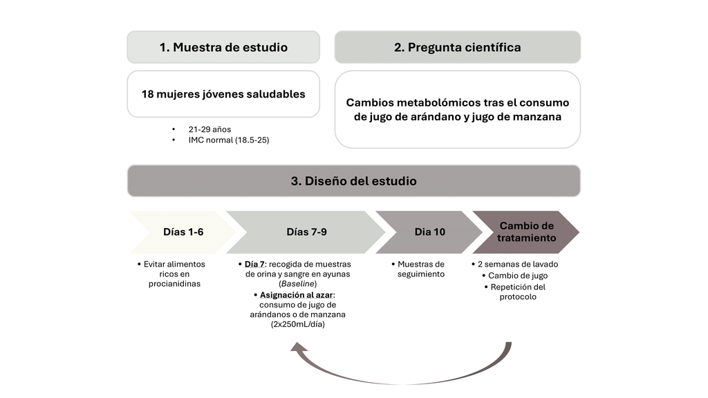

*Figura 2*. Visión general de la recogida de datos del dataset escogido.

Hemos escogido la descarga de los datos ya procesados del estudio desde el primer repositorio de Github mencionado (*Materiales y Métodos*). Para realizar este paso leeremos los archivos *.csv* con la función *read_delim* e imprimiremos los primeros 6 registros de cada conjunto de datos junto con el número de filas y de columnas recogidos en la *Tabla 1*.

```
## [1] "Primeros 6 registros de features.csv"
```

```
##           b1     b10      b11    b12     b13     b14     b15     b16     b17
## [1,]  941000  757000   612000 858000  185000  671000 1140000  108000  383000
## [2,] 8300000 6790000 20800000 320000 1290000 1580000 2340000 1180000 1260000
## [3,]    1500     890 16200000   1250     968     657     809     767     826
## [4,]  276000   35700   631000 369000  242000  472000 5320000   18000  243000
## [5,]  706000  121000 11600000 164000  424000  749000  267000 3050000   99100
## [6,]    6340   34100    31900   9440   92600    6740   14400    8180    8980
##            b2      b4     b6      b7      b8     b9      a1     a10      a11
## [1,]   593000 7240000 494000  812000 1290000  66000  215000  310000   798000
## [2,] 15000000  495000  58100 1350000 1860000 698000 1220000 6920000 18700000
## [3,]     2810    1140   1010     635    1280    664     644    1060     1500
## [4,]   131000  158000 208000  228000  119000  58000   17700  394000  4230000
## [5,]   136000  452000  75600  132000  341000 119000   51600   54900 26700000
## [6,]     4610   10100   8180    5920    1950   1810    4350    1450        0
##          a12     a13     a14     a15    a16    a17      a2       a4     a6
```

[output cut: 20 more lines]

```
## [1] "Primeros 6 registros de metadata.csv"
```

```
## # A tibble: 6 × 2
##   ID    Treatment
##   <chr> <chr>
## 1 b1    Baseline
## 2 b10   Baseline
## 3 b11   Baseline
## 4 b12   Baseline
## 5 b13   Baseline
## 6 b14   Baseline
```

```
## [1] "Primeros 6 registros de metaboliteNames.csv"
```

```
## # A tibble: 6 × 3
##   PubChem  names                                         KEGG
##   <chr>    <chr>                                         <chr>
## 1 5460449  10-Desacetyltaxuyunnanin C                    C15538
## 2 74300    10-Hydroxydecanoic acid                       C02774
## 3 19734156 10-Oxodecanoate_1                             C02217
## 4 21145110 11beta,21-Dihydroxy-5beta-pregnane-3,20-dione C05475
## 5 119521   1,1-Dichloroethylene epoxide                  C14857
## 6 337601   11-Hydroxycanthin-6-one                       C09212
```

Tabla 1: Dimensiones de los conjuntos de datos descargados

| Conjunto de datos | Filas | Columnas |
| --- | --- | --- |
| Features | 1541 | 45 |
| Metadata | 45 | 2 |
| Metabolite Names | 1541 | 3 |

## 2. Contención del conjunto de datos

Una vez tenemos los 3 datasets ubicados, procedemos a guardarlos en un objeto de tipo *SummarizedExperiment*, puesto que este nos permitirá contener los datos de forma completa para poder acceder a ellos de forma fácil.

```
## class: SummarizedExperiment
## dim: 1541 45
## metadata(0):
## assays(1): counts
## rownames(1541): 5460449 74300 ... 11972301 6103
## rowData names(3): PubChem names KEGG
## colnames(45): b1 b10 ... c8 c9
## colData names(2): ID Treatment
```

```
## [1] "Imprimimos los primeros registros de features contenido en el SummarizedExperiment"
```

|  | b1 | b10 | b11 | b12 | b13 | b14 | b15 | b16 | b17 | b2 | b4 | b6 | b7 | b8 | b9 | a1 | a10 | a11 | a12 | a13 | a14 | a15 | a16 | a17 | a2 | a4 | a6 | a7 | a8 | … |
| --- | --- | --- | --- | --- | --- | --- | --- | --- | --- | --- | --- | --- | --- | --- | --- | --- | --- | --- | --- | --- | --- | --- | --- | --- | --- | --- | --- | --- | --- | --- |
| 5460449 | 941000 | 757000 | 612000 | 858000 | 185000 | 671000 | 1140000 | 108000 | 383000 | 593000 | 7240000 | 494000 | 812000 | 1290000 | 66000 | 215000 | 310000 | 798000 | 1070000 | 228000 | 241000 | 1180000 | 15100 | 255000 | 411000 | 463000 | 242000 | 1010000 | 702000 | … |
| 74300 | 8300000 | 6790000 | 20800000 | 320000 | 1290000 | 1580000 | 2340000 | 1180000 | 1260000 | 15000000 | 495000 | 58100 | 1350000 | 1860000 | 698000 | 1220000 | 6920000 | 18700000 | 1320000 | 1230000 | 1980000 | 6980000 | 716000 | 761000 | 2910000 | 11300000 | 689000 | 1350000 | 1130000 | … |
| 19734156 | 1500 | 890 | 16200000 | 1250 | 968 | 657 | 809 | 767 | 826 | 2810 | 1140 | 1010 | 635 | 1280 | 664 | 644 | 1060 | 1500 | 0 | 818 | 660 | 754 | 695 | 562 | 851 | 766 | 637 | 846 | 0 | … |
| 21145110 | 276000 | 35700 | 631000 | 369000 | 242000 | 472000 | 5320000 | 18000 | 243000 | 131000 | 158000 | 208000 | 228000 | 119000 | 58000 | 17700 | 394000 | 4230000 | 3740000 | 361000 | 63300 | 2090000 | 37400 | 13400 | 260000 | 347000 | 151000 | 1080000 | 5080 | … |
| 119521 | 706000 | 121000 | 11600000 | 164000 | 424000 | 749000 | 267000 | 3050000 | 99100 | 136000 | 452000 | 75600 | 132000 | 341000 | 119000 | 51600 | 54900 | 26700000 | 323000 | 152000 | 208000 | 1400000 | 76100 | 16500 | 374000 | 491000 | 81200 | 1000000 | 7000000 | … |
| 337601 | 6340 | 34100 | 31900 | 9440 | 92600 | 6740 | 14400 | 8180 | 8980 | 4610 | 10100 | 8180 | 5920 | 1950 | 1810 | 4350 | 1450 | 0 | 56200 | 3700 | 8360 | 2590 | 1390 | 1090 | 30400 | 2340 | 2930 | 7060 | 2830 | … |
| 441170 | 33900000 | 16000000 | 51200000 | 21900000 | 10700000 | 18800000 | 20400000 | 106000 | 2620000 | 41100000 | 23100000 | 5890000 | 12600000 | 26100000 | 15900000 | 15300000 | 19800000 | 23400000 | 41800000 | 20000000 | 3580000 | 6280000 | 254000 | 4550000 | 29200000 | 23300000 | 1510000 | 19300000 | 30800000 | … |
| 77770 | 8870 | 149000 | 23900 | 28000 | 8690 | 8140 | 6670000 | 216000 | 4120 | 2080 | 725000 | 51300 | 2250 | 109000 | 2320 | 8440 | 71700 | 71400 | 173000 | 2910 | 7280 | 162000 | 23300 | 828 | 17800 | 1250000 | 44600 | 8910 | 52100 | … |
| 1057 | 1870000 | 1520000 | 2470000 | 3090000 | 1380000 | 4060000 | 991000 | 1340000 | 801000 | 2490000 | 1380000 | 289000 | 442000 | 3210000 | 210000 | 1950000 | 840000 | 4780000 | 3170000 | 1430000 | 1480000 | 3090000 | 58600 | 603000 | 7170000 | 260000 | 94900 | 1130000 | 1200000 | … |
| 7823 | 2360000 | 6560000 | 1170000 | 462000 | 562000 | 144000 | 1320000 | 365000 | 605000 | 495000 | 1150000 | 161000 | 603000 | 18900000 | 115000 | 323000 | 252000 | 268000 | 462000 | 362000 | 67300 | 515000 | 66200 | 59100 | 1190000 | 11100000 | 173000 | 287000 | 713000 | … |

De todas maneras, teniendo en cuenta la metodología de la PEC1 y los recursos ofrecidos por la asignatura, crearemos el mismo objeto *SummarizedExperiment* pero con el paquete *POMA*, puesto que contiene también la función de *SummarizedExperiment* para crear este tipo de objeto. Esto nos ayudará en la exploración del dataset en los siguientes apartados.

```
## class: SummarizedExperiment
## dim: 1541 45
## metadata(0):
## assays(1): ''
## rownames(1541): V1 V2 ... V1540 V1541
## rowData names(0):
## colnames(45): b1 b10 ... c8 c9
## colData names(1): Treatment
```

## 4. Exploración de los datos

En este apartado se recogen los resultados del análisis univariante y multivariante que se han realizado en el conjunto de datos escogido.

### 4.1 Análisis univariante

#### 4.1.1 Descriptiva

En primer lugar, empezaremos a explorar nuestro objeto *SummarizedExperiment* mediante un análisis univariante descriptivo de los datos con los que trabajaremos.

Una vez creado el objeto contenedor de nuestros datos (*data_sumexp*), antes de iniciar la exploración del mismo es necesario estudiar la necesidad de procesar los datos. Este procesado es un paso esencial para preparar los datos para su análisis e interpretación posteriores, ya que los datos “brutos” (*raw data*) acostumbran a ser complejos.

En este caso, llevaremos a cabo el procesado mediante un breve análisis descriptivo de nuestro dataset para encontrar posibles datos faltantes (o *missings*) que puedan afectar a su análisis posterior.

```
## [1] "Resumen estadístico breve de nuestras variables"
```

```
##        b1                 b10                 b11
##  Min.   :0.000e+00   Min.   :0.000e+00   Min.   :0.000e+00
##  1st Qu.:1.235e+05   1st Qu.:8.145e+04   1st Qu.:2.240e+05
##  Median :9.100e+05   Median :7.200e+05   Median :1.450e+06
##  Mean   :3.245e+07   Mean   :2.800e+07   Mean   :4.107e+07
##  3rd Qu.:4.980e+06   3rd Qu.:4.500e+06   3rd Qu.:8.050e+06
##  Max.   :1.920e+10   Max.   :1.550e+10   Max.   :2.070e+10
##  NA's   :182         NA's   :182         NA's   :182
##       b12                 b13                 b14
##  Min.   :0.000e+00   Min.   :0.000e+00   Min.   :0.000e+00
##  1st Qu.:1.390e+05   1st Qu.:5.810e+04   1st Qu.:4.435e+04
##  Median :1.010e+06   Median :5.380e+05   Median :4.890e+05
##  Mean   :3.606e+07   Mean   :2.452e+07   Mean   :2.227e+07
##  3rd Qu.:5.545e+06   3rd Qu.:3.095e+06   3rd Qu.:2.925e+06
##  Max.   :2.300e+10   Max.   :1.130e+10   Max.   :1.240e+10
##  NA's   :182         NA's   :182         NA's   :182
##       b15                 b16                 b17
##  Min.   :0.000e+00   Min.   :0.000e+00   Min.   :0.000e+00
##  1st Qu.:1.070e+05   1st Qu.:2.560e+04   1st Qu.:2.635e+04
##  Median :8.560e+05   Median :2.940e+05   Median :2.910e+05
##  Mean   :3.086e+07   Mean   :1.551e+07   Mean   :1.270e+07
##  3rd Qu.:4.920e+06   3rd Qu.:1.940e+06   3rd Qu.:1.675e+06
##  Max.   :1.650e+10   Max.   :7.320e+09   Max.   :6.810e+09
##  NA's   :182         NA's   :182         NA's   :182
##        b2                  b4                  b6
##  Min.   :0.000e+00   Min.   :0.000e+00   Min.   :0.000e+00
##  1st Qu.:1.565e+05   1st Qu.:1.620e+05   1st Qu.:3.615e+04
##  Median :9.160e+05   Median :1.250e+06   Median :3.740e+05
##  Mean   :3.124e+07   Mean   :4.695e+07   Mean   :2.116e+07
##  3rd Qu.:5.070e+06   3rd Qu.:7.130e+06   3rd Qu.:2.830e+06
##  Max.   :1.700e+10   Max.   :2.610e+10   Max.   :1.270e+10
##  NA's   :182         NA's   :182         NA's   :182
##        b7                  b8                  b9
##  Min.   :0.000e+00   Min.   :0.000e+00   Min.   :0.000e+00
##  1st Qu.:4.225e+04   1st Qu.:1.435e+05   1st Qu.:1.520e+04
##  Median :4.540e+05   Median :1.070e+06   Median :2.090e+05
##  Mean   :1.688e+07   Mean   :2.841e+07   Mean   :1.288e+07
##  3rd Qu.:2.710e+06   3rd Qu.:5.615e+06   3rd Qu.:1.475e+06
##  Max.   :7.870e+09   Max.   :1.430e+10   Max.   :6.970e+09
##  NA's   :182         NA's   :182         NA's   :182
```

[output cut: 65 more lines]

```
##  Min.   :0.000e+00   Min.   :0.000e+00   Min.   :0.000e+00   Min.   :0.00e+00
##  1st Qu.:1.095e+05   1st Qu.:4.110e+04   1st Qu.:1.180e+05   1st Qu.:2.31e+04
##  Median :8.590e+05   Median :5.200e+05   Median :8.790e+05   Median :3.06e+05
##  Mean   :4.522e+07   Mean   :1.774e+07   Mean   :3.881e+07   Mean   :2.12e+07
##  3rd Qu.:5.310e+06   3rd Qu.:2.865e+06   3rd Qu.:5.245e+06   3rd Qu.:2.35e+06
##  Max.   :2.110e+10   Max.   :1.060e+10   Max.   :1.710e+10   Max.   :9.75e+09
##  NA's   :182         NA's   :182         NA's   :182         NA's   :182
##        c8                  c9
##  Min.   :0.000e+00   Min.   :0.000e+00
##  1st Qu.:8.745e+04   1st Qu.:2.650e+04
##  Median :7.260e+05   Median :3.020e+05
##  Mean   :2.937e+07   Mean   :1.814e+07
##  3rd Qu.:4.345e+06   3rd Qu.:2.265e+06
##  Max.   :1.480e+10   Max.   :7.420e+09
##  NA's   :182         NA's   :182
```

```
## [1] "Búsqueda de valores faltantes"
```

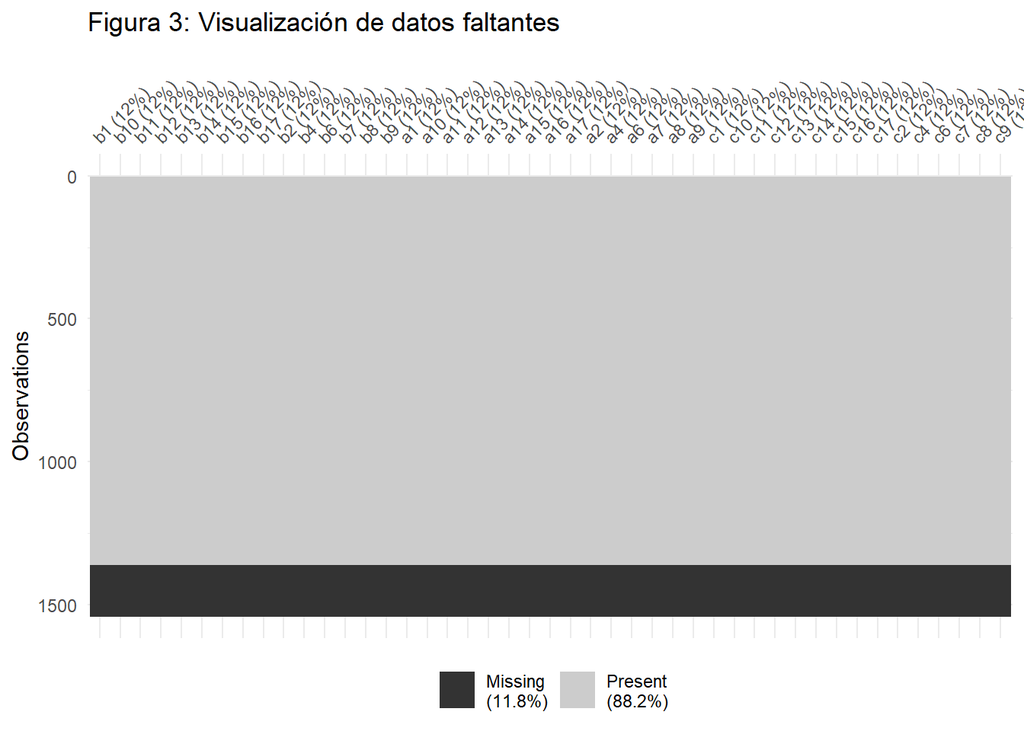

Efectivamente, en el gráfico generado podemos observar que existe un 11.8% de datos faltantes en el dataset. Esto es fácilmente solucionable con la función *PomaImpute*.

Ahora que ya tenemos una base de datos limpia, nos fijaremos en las distribuciones de los datos en cuestión. En este punto, debemos tener en cuenta que tratamos con un tamaño de muestra limitado (45) en comparación con el número de variables analizadas (1359). Por lo tanto, este estudio descriptivo lo enfocaremos a los individuos de la muestra, y no a los metabolitos como normalmente haríamos. Esto nos ayuda a poder visualizar y entender de forma más sencilla los datos. Para ello, con las funciones *PomaDensity* y *PomaBoxplots* crearemos un gráfico de distirbución y un gráfico de cajas, respectivamente.

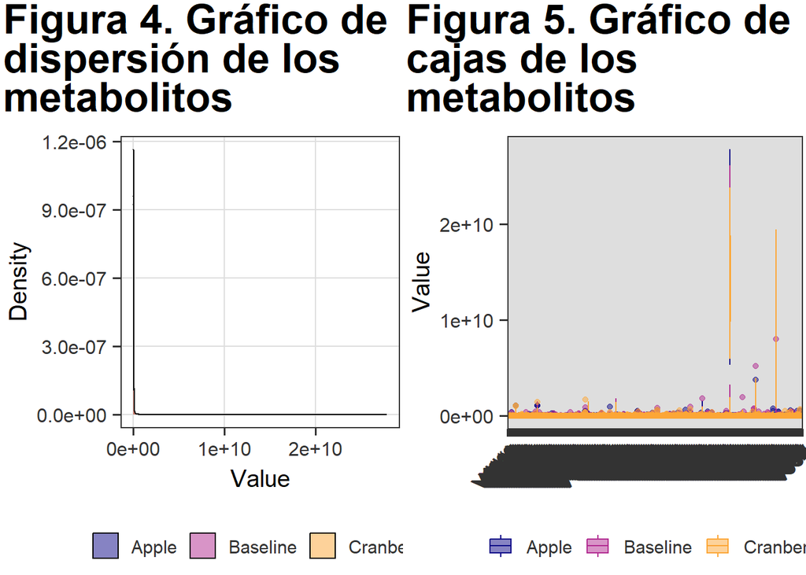

Prestando atención a las *Figuras 4 y 5* claramente detectamos una distribución irregular de los datos. No solo en el prime gráfico, sino también lo vemos en el gráfico de cajas, dónde ni siquiera podemos intuir las cajas de cada sujeto por la gran dispersión que estas presentan. Esta presentación de los datos nos ayuda a entender que será necesario transformar los datos con el objetivo de facilitar el análisis posterior. En este caso, proponemos realizar una transformación logarítmica del conjunto de datos mediante la función *PomaNorm*.

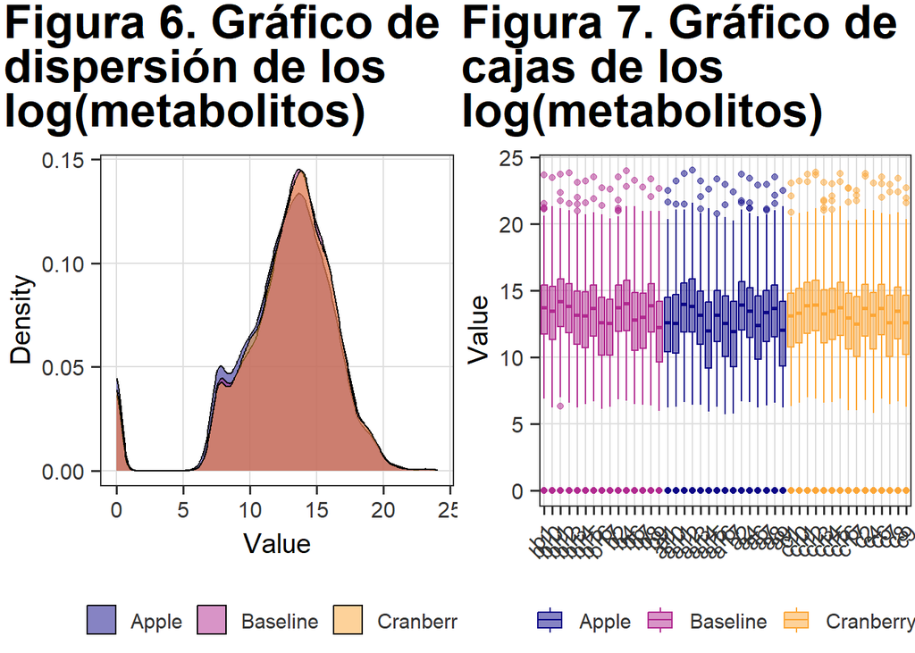

Visualmente ya detectamos una mejora notable en la distribución de los datos.

Cabe destacar que aunque este proceso lo estamos llevando a cabo generando un nuevo objeto con funciones del paquete *POMA*, también podemos realizar esta transformación de los datos y guardarlos en el mismo objeto creado inicialmente. En este caso, lo guardaremos como una nueva *assay*.

```
## class: SummarizedExperiment
## dim: 1359 45
## metadata(0):
## assays(2): '' logcounts
## rownames(1359): V1 V2 ... V1358 V1359
## rowData names(0):
## colnames(45): b1 b10 ... c8 c9
## colData names(1): Treatment
```

Para acabar con este análisis descriptivo, también seria interesante estudiar la distancia entre los valores de cada individuo de la muestra. Dado que no podemos graficar directamente la correlación, puesto que estamos centrándonos en los individuos, calcularemos y graficaremos estas distancias usando el paquete *factoextra*.

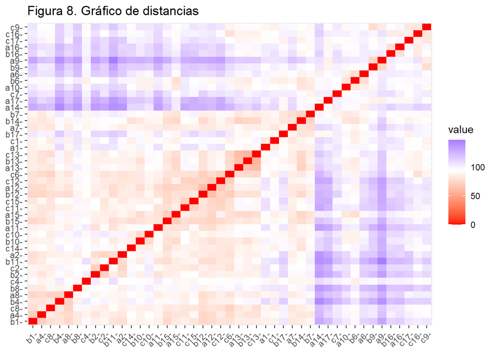

### 4.2 Análisis multivariante

#### 4.2.1 Análisis de componentes principales (PCA)

Como ya hemos ido explorando, nuestro conjunto de datos cuenta con 1359 metabolitos y su tamaño mostral es de 45, hallazgo que implica una dimensionalidad bastante elevada para cualquier análisis que podamos hacer. Por ese motivo, realizaremos un análisis multivariante usando el análisis de componentes principales (PCA) para reducir esta dimensionalidad y ajustar nuestra base de datos a las demandas estadísticas necesarias.

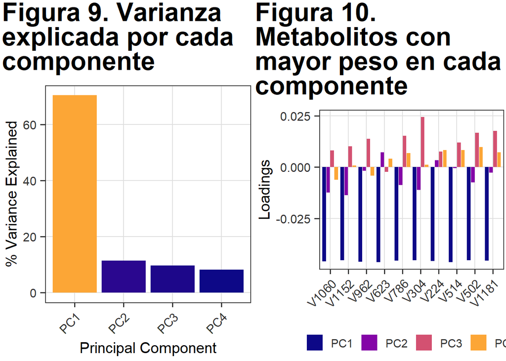

Y a continuación usaremos la función *pca* del paquete *PCAtools* para graficar la disposición de las dos primeras componentes en un gráfico con sus respectivas proyecciones entre tratamientos en el mismo.

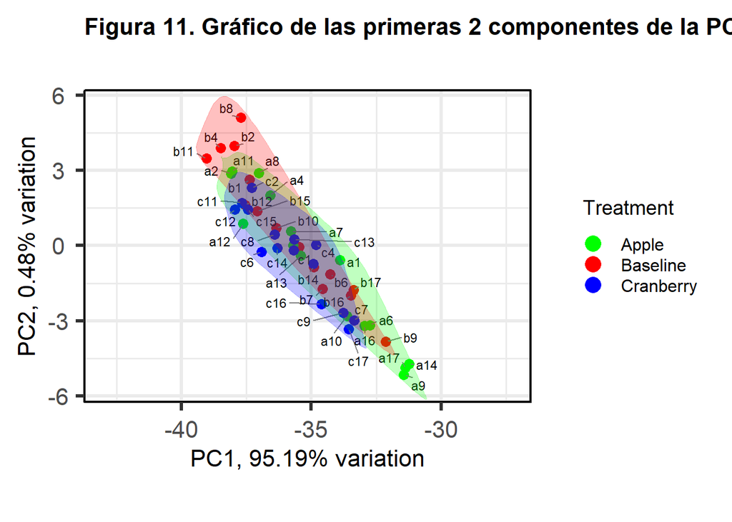

#### 4.2.2 Clustering

Finalmente, mediante técnicas de clustering estudiaremos la posibilidad de encontrar patrones diferenciales en el perfil metabolómico de estudio.

En primer lugar, realizaremos una clusterización de tipo jerárquico.

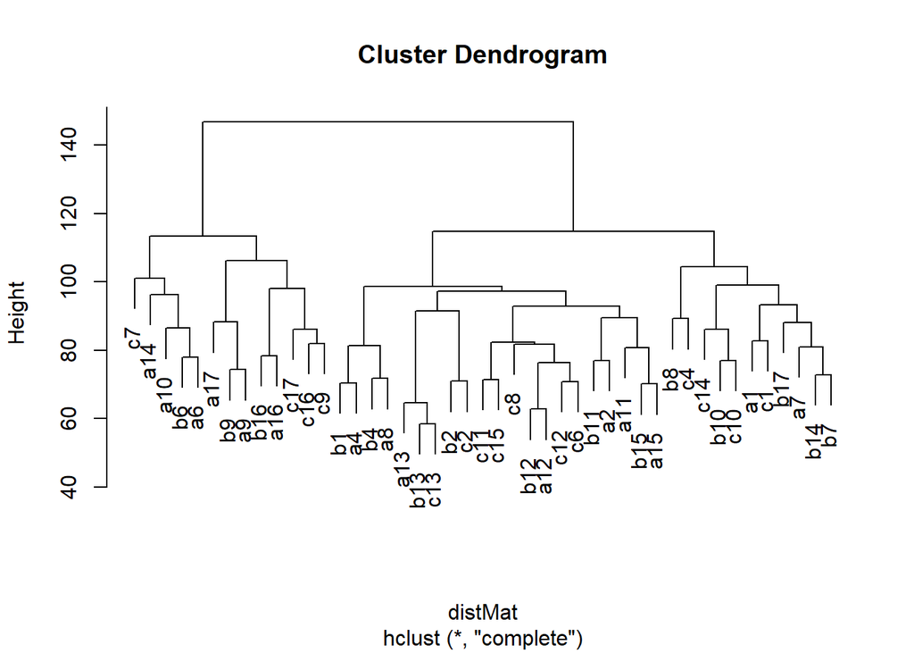

Tal y como podemos evidenciar en el dendograma, existen 2 clústers distintos en nuestro dataset. Este hallazgo continua en la línea de los resultados obtenidos en los 2 apartados anteriores, sustentando la posibilidad de que la variable categórica de tres niveles *Tratamiento* no participe en las diferencias en el perfil metabolómico de la muestra, sino otra fuente de variabilidad que caracterice dos agrupaciones de la misma muestra.

# *Discusión*

## Limitaciones

Como en todo estudio, esta PEC1 ha enfrentado una serie de limitaciones que merece la pena destacar. En primer lugar, la elección del dataset en ambos repositorios propuestos fue un desafío. En mi caso, seleccioné un conjunto de datos del primer repositorio de **GitHub**, ya que el segundo (*metabolomicsWorkbench*) resultó difícil de entender debido a su interfaz web compleja y a la lentitud en la descarga de archivos. Sin embargo, mi elección también presentó dificultades, ya que fue necesario trabajar con el formato de las variables en cada archivo descargado en Excel debido a una leve desorganización que complicaba la creación del objeto contenedor *SummarizedExperiment*. En segundo lugar, aunque esta PEC1 me ha permitido comprender mejor los detalles de este contenedor de datos, encontré relativamente poca información sobre el paquete. Aunque en los materiales de la asignatura se mencionaba *SummarizedExperiment*, no se trabajó con ningún ejemplo. Además, el único enlace referenciado en los apuntes no funcionaba. Aun así, he aprendido a buscar en diferentes repositorios información y scripts del proceso, lo cual me ha ayudado en gran medida a fijarme más en el código y a entender mejor lo que estaba haciendo.

[figure not shown]

*Figura 12*. Error en el link (Actividad 1.3).

## Conclusión

En conclusión, en esta primera entrega de la asignatura he adquirido conocimientos tanto sobre diversas herramientas bioinformáticas como sobre el proceso previo de exploración necesario del conjunto de datos del estudio. Esto me ha ayudado a comprender en gran medida la naturaleza de este tipo de datos, así como la forma de tratarlos adecuadamente para asegurar un análisis preciso.

# Descarga de datos para Github

# Bibliografía

[Informes en Rmarkdown](https://tutorialesmg.netlify.app/r-markdown#cap%C3%ADtulo-4--personalizaci%C3%B3n-del-informe-%5D)

[Información del dataset](https://pcastellanoescuder.github.io/fobitools/articles/MW_ST000291_enrichment.html)

[Bioconductor: SummarizedExperiment](https://bioconductor.org/packages/release/bioc/html/SummarizedExperiment.html)

[SummarizedExperiment](https://bioconductor.org/packages/release/bioc/vignettes/SummarizedExperiment/inst/doc/SummarizedExperiment.html)

[SummarizedExperiment 2](https://carpentries-incubator.github.io/bioc-project/09-summarizedexperiment.html)

[Paquete POMA](https://bioconductor.org/packages/3.21/bioc/manuals/POMA/man/POMA.pdf)

[POMA Workflow](https://bioconductor.org/packages/devel/bioc/vignettes/POMA/inst/doc/POMA-workflow.html)

[Normalización de datos con POMA](https://www.bioconductor.org/packages/devel/bioc/vignettes/POMA/inst/doc/POMA-normalization.html)

[RNA-Seq analysis with R and Bioconductor](https://uclouvain-cbio.github.io/bioinfo-training-02-rnaseq/sec-se.html)

[Distancias en clustering](https://www.datanovia.com/en/lessons/clustering-distance-measures/)

[Cluster Analysis](https://agroninfotech.blogspot.com/2020/06/cluster-analysis-in-r.html#google_vignette)